# Mapping with R

Kent Johnson  
kent@kentsjohnson.com

2015-09-13

# Maps in R? Why?

- R has good support for spatial data including shapefiles, GeoJSON, spatial operations  
  `rgdal::writeOGR()` writes GeoJSON directly
- Support for data manipulation, general graphics, statistics
- Great reporting capabilities with `knitr` and `rmarkdown`  
  This presentation was authored in R and markdown  
  A more detailed example: http://kentsj.com/FPRA/TownGown.html
- Capable programming language
- Use `knitr` and `leaflet` to embed interactive maps in HTML pages
- Growing support for interactive HTML reports with no JavaScript coding required!
- RStudio is a *great* programming environment

# Maps in R? Why not?

- It’s programming :-)
- R is a quirky programming language and can take some time to learn
- Interactive capabilities are less than what you can do directly in Javascript

# Today’s goal

Make a map showing Cambridge properties built since 1980, color-coded by year built.

Data is from the Cambridge Open Data portal (http://data.cambridgema.gov).

- Assessor’s data gives parcel address, year built
- Parcel shapefile contains the parcel outlines

# RStudio

- Very quick orientation for those following along

# Libraries

```r
library(rgdal)
library(leaflet)
```

- `rgdal` package supports reading and writing shapefiles
- `leaflet` package (http://rstudio.github.io/leaflet/) connects to `leaflet.js`
- Install with `install.packages(c('rgdal', 'leaflet'))` or the *Packages* tab in RStudio

# Load the assessor’s data

```r
# https://data.cambridgema.gov/Assessing/Assessing-Building-Information/crnm-mw9n
ass2015 = read.csv('data/Assessing_Building_Information.csv',
               stringsAsFactors=FALSE)
```

- `read.csv` loads a .csv file into an R data.frame.
- `stringsAsFactors=FALSE` prevents conversion of string columns into categorical variables.

# Explore assessor’s data

```r
nrow(ass2015)
```

```
[1] 25612
```

```r
names(ass2015)
```

```
 [1] "Account.Number"            "Neighborhood..Market.Area" "Location"
 [4] "GIS.ID"                    "Building.No"               "Building.Type"
 [7] "State.Use"                 "Land.Area"                 "Bldg.Stories"
[10] "Living.Area"               "Actual.Year.Built"         "Eff.Yr.Code"
[13] "Style.Desc"                "Grade"                     "Ext.Wall"
[16] "Num.Bedrm"                 "Num.Baths"                 "Total.Assessed.Land.Value"
[19] "Assessed.Value"            "Owner.Name"                "Owner.s.Name2"
[22] "Mailing.Address"           "City"                      "State"
[25] "Zip"
```

- `nrow` shows the number of rows in the table
- `names` shows the column names in the table
- Notice all special characters in column names have been changed to periods.

# Explore assessor’s data

```r
summary(ass2015$Actual.Year.Built)
```

```
   Min. 1st Qu.  Median    Mean 3rd Qu.    Max.    NA's
      0    1890    1920    1910    1960    2010       1
```

```r
head(table(ass2015$Actual.Year.Built), n=50)
```

```
   0 1389 1700 1730 1750 1751 1757 1760 1765 1767 1768 1777 1790 1793 1796 1797 1800 1803 1804 1805
 139    1    4    2    1    2    1    2    1    1    1    1    1    2    9    1    8    4    2    2
1806 1807 1808 1810 1812 1813 1814 1817 1820 1821 1822 1823 1824 1825 1826 1827 1828 1829 1830 1831
   5    2    3    3    2    1    2    1   13    8    3    1    3    4    8    2    4    5   30    2
1832 1833 1834 1835 1836 1837 1838 1839 1840 1841
   2    5    3    5    4   14   17   27   52   14
```

```r
# table(ass2015$Actual.Year.Built)
```

- `summary` gives a simple summary of numerical data
- `table` tabulates values in the year built column.
- In RStudio: `View(ass2015)` or clicking the variable in *Environment* gives a sortable, searchable table view

# Filter out old & duplicate properties

```r
ass_new = subset(ass2015, Actual.Year.Built>=1980)
ass_new = ass_new[!duplicated(ass_new$GIS.ID),]
```

- `subset` selects properties built in 1980 or later
- `duplicated` finds entries which have already appeared in a vector
- There may be multiple properties on one parcel (e.g. condos)
- We just need one property to identify the parcel

# Explore

```r
table(ass_new$Actual.Year.Built)
```

```
1980 1981 1982 1983 1984 1985 1986 1987 1988 1989 1990 1991 1992 1993 1994 1995 1996 1997 1998 1999
  47   47   77   16  101   70   46   43   40   26   26    8   13    9   22   16   16   18   29   20
2000 2001 2002 2003 2004 2005 2006 2007 2008 2009 2010 2011 2012 2013 2014
  27   24   28   18   23   26   26   15   21   16   13   12   25   32    2
```

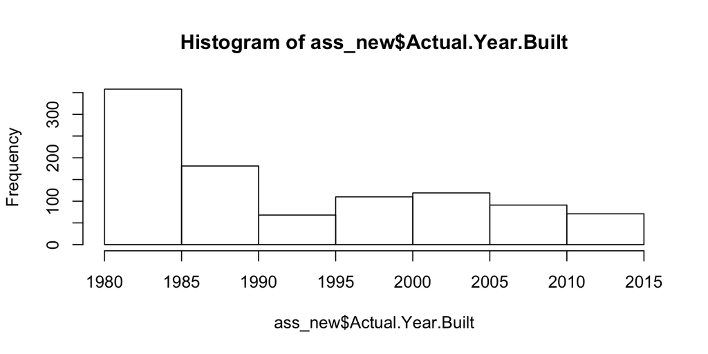

```r
hist(ass_new$Actual.Year.Built)
```

# Read parcel shapefile

```r
# https://data.cambridgema.gov/Assessing/Parcels-Fiscal-Year-2015/rst6-227j
parcels2015 = readOGR('data/ASSESSING_ParcelsFY2015.shp',
        'ASSESSING_ParcelsFY2015', stringsAsFactors=FALSE)
names(parcels2015)
```

```
 [1] "ML"         "MAP"        "LOT"        "UYEAR"      "Editor"     "EditDate"   "LOC_ID"
 [8] "POLY_TYPE"  "SOURCE"     "PLAN_ID"    "created_us" "created_da" "last_edite" "last_edi_1"
[15] "SHAPE_STAr" "SHAPE_STLe"
```

```r
# View(parcels2015@data)
```

- `readOGR` returns a `SpatialPolygonsDataFrame` which combines the parcel shapes with a data.frame
- `parcels2015@data` is the data.frame
- `parcels2015@polygons` contains the polygon data.

# Merge

```r
new_parcels = parcels2015[parcels2015$ML %in% ass_new$GIS.ID,]
new_parcels = merge(new_parcels, ass_new, by.x='ML', by.y='GIS.ID')
```

- Subset the parcel data to just the ones we want
- Parcel ID is `ML` (map-lot) in the parcel data and `GIS.ID` in the assessor’s data.
- Use indexing to select (could also use `subset`)
- `%in%` creates a boolean vector
- Merge property data with parcel shapes to make a single data set

# A simple map

The `plot` method will make a simple map of spatial data.

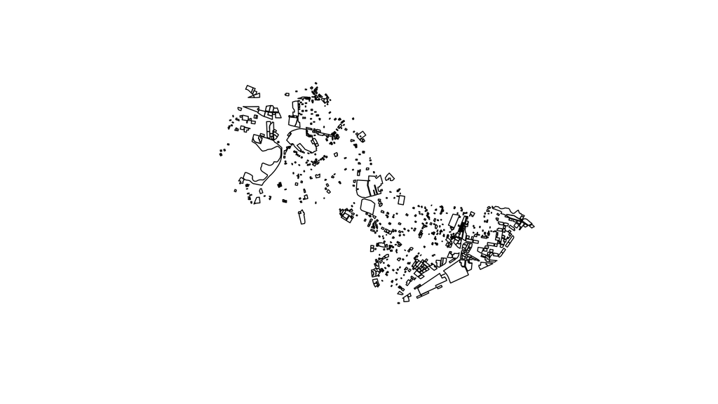

```r
plot(new_parcels)
```

# A simple map

- It’s not much but it verifies that we have reasonable spatial data
- We could add color, political boundaries, etc. to make a real map
- Slippy maps are more fun!

# Transform to WGS 84 for web mapping

```r
new_osm = spTransform(new_parcels, CRS("+init=EPSG:4326"))
```

- Cambridge data is in Massachusetts State Plane coordinates
- Web maps use WGS 84 *aka* epsg:4326
- If your data doesn’t show up, this might be the reason

# First slippy map

The R API to leaflet.js is patterned on the Javascript API.

```r
leaflet() %>%
  addTiles() %>%
  setView(-71.128184, 42.3769824, zoom = 14) %>%
  addPolygons(data=new_osm)
```

- `leaflet()` creates the map object
- `addTiles()` creates the background tiled layer
- `setView()` sets the initial location and zoom
- `addPolygons()` adds our data to the map as a polygon overlay
- `%>%` is a pipe operator

# First slippy map

[interactive chart not shown]

# Change the base layer

Stamen Design’s `toner-lite` is a good base map, it stays out of the way.

```r
base_map = leaflet() %>%
  addProviderTiles('Stamen.TonerLite') %>%
  setView(-71.128184, 42.3769824, zoom = 14)
```

- Save the base map in a variable to reduce repetition later
- `addProviderTiles()` takes the name of a provider
- **Many** tile providers, see http://leaflet-extras.github.io/leaflet-providers/preview/

# Change the base layer

```r
base_map %>%
  addPolygons(data=new_osm)
```

[interactive chart not shown]

# Color

```r
palette = c('#fed976', '#feb24c', '#fd8d3c',
            '#fc4e2a', '#e31a1c', '#bd0026', '#800026')

year_built = new_parcels@data$Actual.Year.Built
colors = palette[cut(year_built, c(seq(1980, 2010, 5), 2015),
                     include.lowest=TRUE, labels=FALSE)]
```

- `palette` is the actual colors  
  From the 9-class YlOrRd ColorBrewer palette  
  http://colorbrewer2.org/?type=sequential&scheme=YlOrRd&n=9
- `colors` is a vector of colors, one per property, selected from `palette`
- Use one color per five-year period
- `cut` divides the years into ranges

# Color

```r
base_map %>%
  addPolygons(data=new_osm,
              color='black', fillColor=colors) # Colors
```

[interactive chart not shown]

# Popups

- Popups are HTML, build them in R using `apply` and `paste`

```r
# Make popups showing the location and year built.
popups = apply(new_parcels@data, 1, function(parcel) {
         paste0('<p>', parcel['Location'], '<br>',
         'Year: ', parcel['Actual.Year.Built'], '<br></p>')
         })
```

- `apply` performs an operation on each element along one dimension (here, for each row)
- `paste0` concatenates strings

# Popups

```r
base_map %>%
  addPolygons(data=new_osm,
              color='black', fillColor=colors, # Colors
              popup=unname(popups),            # Popups
              options=c(pathOptions(), popupOptions(minWidth=100)))
```

[interactive chart not shown]

# A little more styling and we’re done

See the `leaflet.js` docs for available options.

```r
base_map %>%
  addPolygons(data=new_osm,
              color='black', fillColor=colors, # Colors
              weight=1, dashArray=1,           # Line weight
              opacity=0.7, fillOpacity=0.5,    # Transparency
              popup=unname(popups),            # Popups
              options=c(pathOptions(), popupOptions(minWidth=100)))
```

# Final map

[interactive chart not shown]

# Links

- R home page  
  https://www.r-project.org/
- RStudio IDE  
  https://www.rstudio.com/products/RStudio/
- `leaflet` package for R  
  http://rstudio.github.io/leaflet/
- A more detailed tutorial on spatial analysis and mapping in R  
  http://robinlovelace.net/r/2014/01/30/spatial-data-with-R-tutorial.html
- More on static maps  
  http://www.molecularecologist.com/2012/09/making-maps-with-r/